# Introducción al Universo R

Trabajando con series de tiempo en R

Profesor: Cristian Camilo Hoyos

Departamento de Economía - Universidad Icesi

[figure not shown]

# Instrucciones

En este html encontrarán cómo trabajar con objetos de series de tiempo en R.

**Consejo**: Escriba todo código en un **script**

Note que el archivo es un archivo RData, para lo cual puede cargarlo de la siguiente manera:

```r
load("desempleo.RData")
```

O puede dar clic derecho sobre el archivo en tu sistema de archivos, seleccionar la opción “abrir con” y finalmente dar clic en “Rstudio”.

En tu environment, aparecerá una base de datos llamada “datos” con 286 filas y 4 columnas.

# Objeto ts

El objeto tal vez más tradicional de series de tiempo es el objeto **ts**, la función para crear o convertir un objeto a series de tiempo es la función **ts()**, esta función requiere los datos a ser transformados o creados, una fecha de inicio (argumento **start**), opcional una fecha final (argumento **end**) y la frecuencia de los datos (argumento **frequency**). Este último puede ser diario (frequency = 365), semanal (frequency = 52), mensual (frequency = 12), trimestral (frequency = 4), semestral (frequency = 2) o anual (frequency = 1). Transformemos la tasa de desempleo mensual contenida en el objeto **datos** a objeto ts:

```r
desempleo_ts = ts(datos$TD, start = c(2001,1),end = c(2024,10), frequency = 12)
```

Podemos comprobar qué clase es el objeto:

```r
class(desempleo_ts)
```

```
## [1] "ts"
```

Como podemos ver, el nuevo objeto es clase **ts**. Con estos objetos podemos utilizar diferentes funciones, como por ejemplo **periodicity**:

```r
library(xts)
periodicity(desempleo_ts)
```

```
## Monthly periodicity from ene. 2001 to oct. 2024
```

Otra función bastante útil en el mundo de las series de tiempo es **lag**, esta función permite rezagar la serie. Básicamente es correr los datos una fecha hacia atrás, veamos:

```r
lag(desempleo_ts)
```

```
##            Jan       Feb       Mar       Apr       May       Jun       Jul
## 2000
## 2001 16.063858 16.533120 13.661022 14.746763 15.042568 15.153537 14.822665
## 2002 14.807452 15.797366 15.345203 15.604164 15.672274 15.402312 15.858629
## 2003 14.463107 13.710280 14.384986 13.244050 13.964758 14.502443 14.274142
## 2004 14.395468 13.998907 14.201473 14.075655 14.037054 12.857521 12.975239
## 2005 12.748015 13.278709 11.697435 12.594932 11.610871 11.941416 11.663082
## 2006 11.798801 11.503061 11.879869 11.889337 10.627277 12.058646 13.069236
## 2007 11.629282 12.030337 10.679172 11.701869 11.389999 10.942790 10.974675
## 2008 11.039245 11.283586 10.959021 10.814606 11.631732 11.652227 11.654805
## 2009 11.602551 12.167863 11.975991 11.758559 11.798182 12.207793 12.241710
## 2010 11.486342 11.987231 12.276966 12.234283 12.207333 12.195392 11.736108
## 2011 11.805598 11.005388 11.086778 11.515984 11.289044 11.071117 10.783496
## 2012 10.673204 10.535119 10.926224 10.946017 10.517805 10.627954 10.299196
## 2013 10.537341 10.343278 10.341347  9.791594  9.823347  9.717108  9.913754
```

[output cut: 37 more lines]

Comparemos con los datos originales:

```r
desempleo_ts
```

```
##            Jan       Feb       Mar       Apr       May       Jun       Jul
## 2001 14.312730 16.063858 16.533120 13.661022 14.746763 15.042568 15.153537
## 2002 15.643511 14.807452 15.797366 15.345203 15.604164 15.672274 15.402312
## 2003 14.020412 14.463107 13.710280 14.384986 13.244050 13.964758 14.502443
## 2004 15.119853 14.395468 13.998907 14.201473 14.075655 14.037054 12.857521
## 2005 11.109532 12.748015 13.278709 11.697435 12.594932 11.610871 11.941416
## 2006 11.254825 11.798801 11.503061 11.879869 11.889337 10.627277 12.058646
## 2007 12.019297 11.629282 12.030337 10.679172 11.701869 11.389999 10.942790
## 2008 11.027841 11.039245 11.283586 10.959021 10.814606 11.631732 11.652227
## 2009 12.175218 11.602551 12.167863 11.975991 11.758559 11.798182 12.207793
## 2010 12.672675 11.486342 11.987231 12.276966 12.234283 12.207333 12.195392
## 2011 11.739263 11.805598 11.005388 11.086778 11.515984 11.289044 11.071117
## 2012 10.703615 10.673204 10.535119 10.926224 10.946017 10.517805 10.627954
## 2013 10.245893 10.537341 10.343278 10.341347  9.791594  9.823347  9.717108
## 2014  9.406861  9.618051  9.704732  9.275221  9.040565  9.761773  9.308853
```

[output cut: 35 more lines]

Noten que los valores se corrieron una fecha hacia atrás, es decir, el valor que correspondía a octubre de 2024 ahora quedó con fecha de septiembre de 2024. Esta función es útil para modelamiento y tratamiento de las series de tiempo, no te preocupes, lo verás nuevamente en siguientes cursos.

## Graficando un objeto ts

Existen algunas funciones que nos permiten graficar de manera rápida una serie de tiempo, sin necesidad de emplear la estructura ya conocida de ggplot vista en módulos pasados. Una función que usa los gráficos base de R es **plot.ts**, y solo requiere que le pasemos el objeto con la serie de tiempo.

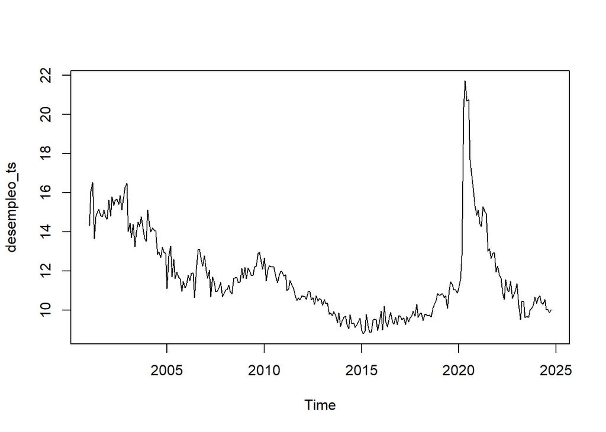

```r
plot.ts(desempleo_ts)
```

Otra función es **autoplot** del paquete **forecast**, esta función es mejor porque usa ggplot para graficar, lo cual permite editar el gráfico como ya vimos en el módulo de visualizaciones.

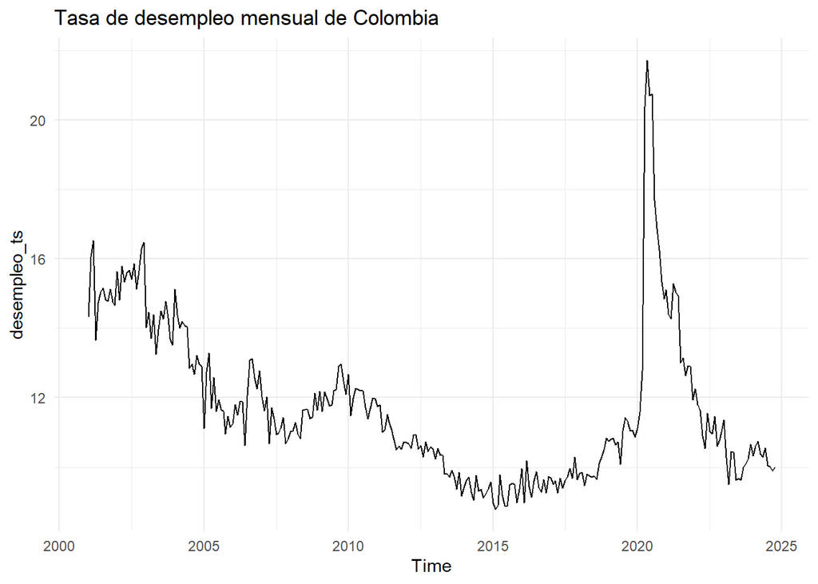

```r
library(forecast)
library(ggplot2)
autoplot(desempleo_ts) + ggtitle("Tasa de desempleo mensual de Colombia") + theme_minimal()
```

Finalmente, es importante mencionar que en un mismo objeto **ts** se pueden almacenar 2 o más series de tiempo, usemos por ejemplo la tasa de ocupación y la tasa de desempleo:

```r
laboral_ts = ts(datos[,c("TD","TO")], start = c(2001,1),end = c(2024,10), frequency = 12)

class(laboral_ts)
```

```
## [1] "mts"    "ts"     "matrix"
```

Noten que adicionalmente a la clase **ts** ahora el objeto tiene 2 clases adicionales: **mts** y **matrix**.

Grafiquemos las series:

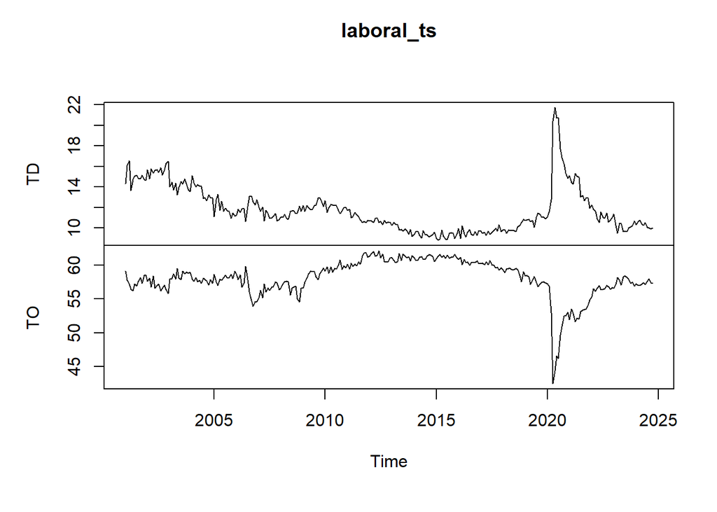

```r
plot.ts(laboral_ts)
```

Noten que automáticamente la función **plot.ts** grafica las dos series. Esto también lo hace la función autoplot:

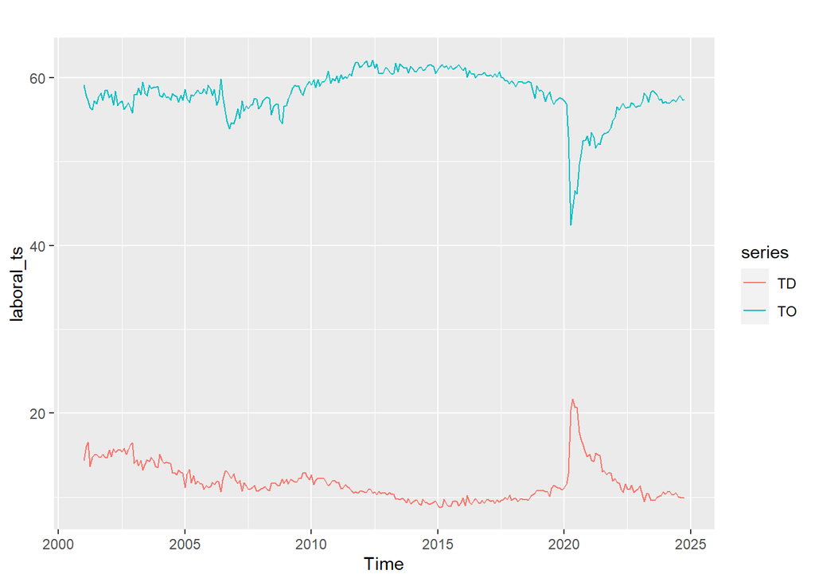

```r
autoplot(laboral_ts)
```

# Objeto xts

Otro objeto muy usado en R para trabajar con series de tiempo es el objeto **xts**, para esto necesitamos cargar el paquete con el mismo nombre. A continuación creemos un objeto con la tasa de desempleo:

```r
library(xts)
datos$fecha = as.Date(datos$fecha)
desempleo_xts = xts(datos$TD, order.by = datos$fecha)
class(desempleo_xts)
```

```
## [1] "xts" "zoo"
```

La función **xts** requiere un vector o matriz de datos y un vector de fechas en formato **Date**. Como pueden ver en la segunda línea de código hacemos la transformación a formato fecha. En este caso, la fecha ya se encontraba en el formato que toma por default R para transformar a fecha: **“YYYY-mm-dd”**, sin embargo, si la fecha en la base de datos se encuentra en un orden diferente, usando el argumento **format** puede indicar el orden en el que se encuentra la fecha.

También es posible transformar un objeto de claase **ts** a **xts**:

```r
desempleo_xts_2 = as.xts(desempleo_ts)
class(desempleo_xts_2)
```

```
## [1] "xts" "zoo"
```

## Graficando objetos xts

Para graficar las series de tiempo almacenadas en la clase **xts** podemos emplear la función **plot.xts**:

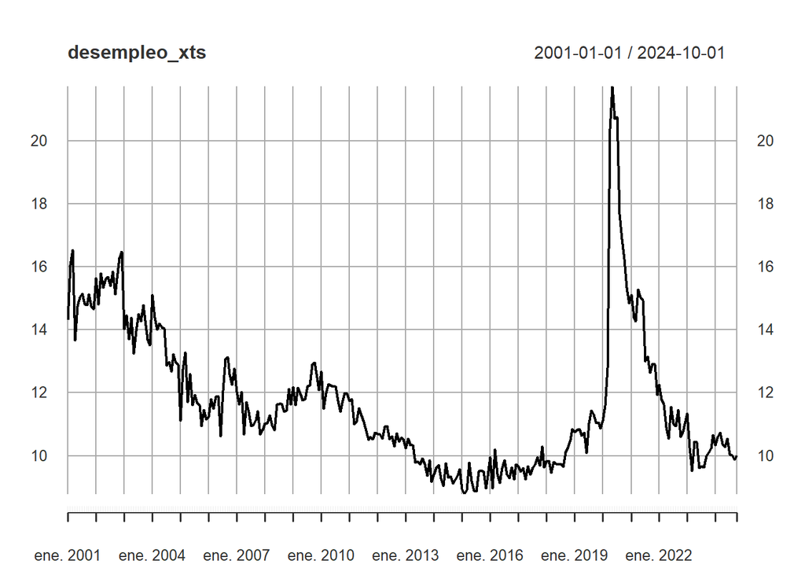

```r
plot.xts(desempleo_xts)
```

El resultado es un gráfico rápido con un formato un poco mejor estéticamente que el resultado de un gráfico de un objeto **ts**. No obstante, la opción del autoplot también es posible para este tipo de objetos:

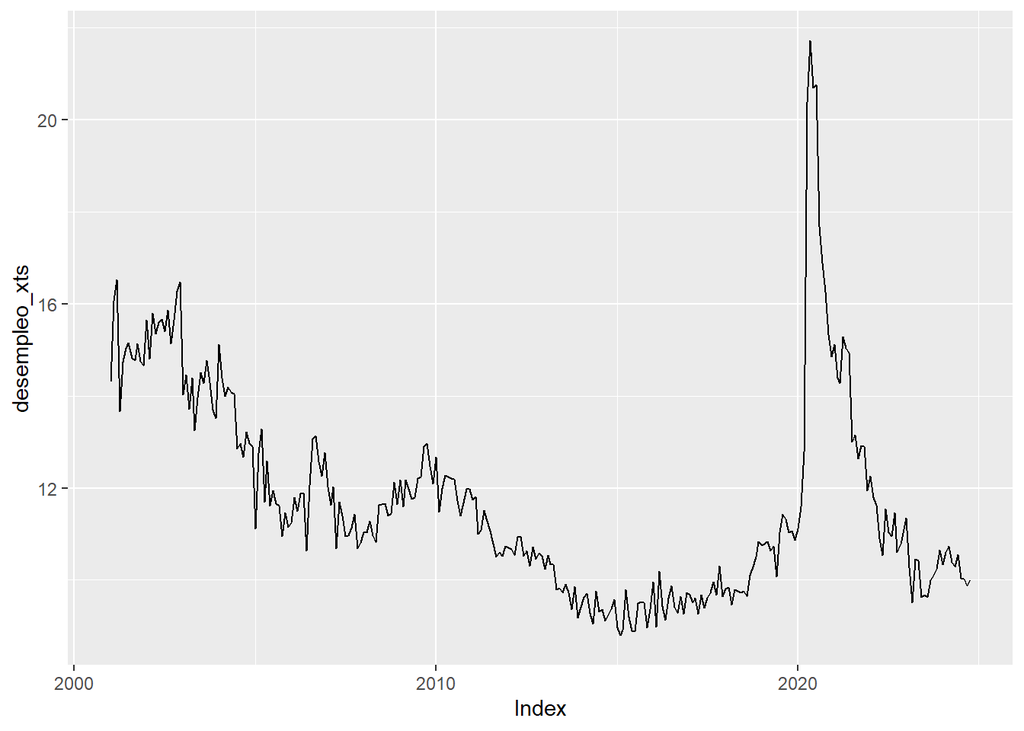

```r
autoplot(desempleo_xts)
```

Por último, al igual que en los objetos **ts**, podemos almacenar varias series de tiempo en un objeto **xts**:

```r
laboral_xts = xts(datos[,c(1:3)], order.by = datos$fecha)
class(laboral_xts)
```

```
## [1] "xts" "zoo"
```

Grafiquemos este objeto:

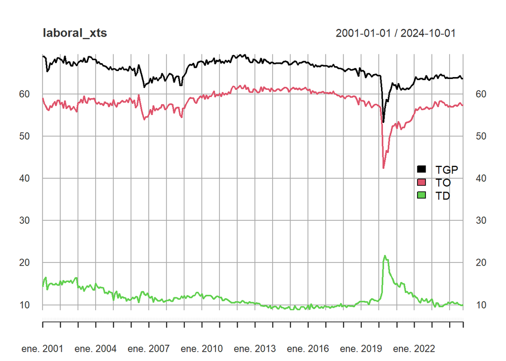

```r
plot.xts(laboral_xts, legend.loc = "right")
```

# Descomposición de una serie de tiempo:

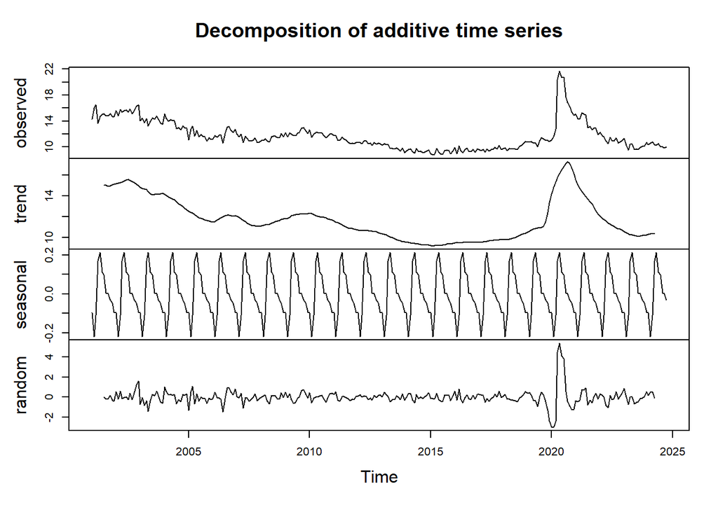

```r
TD.componentes <- decompose(desempleo_ts)

plot(TD.componentes)
```

De esta manera, terminamos la introducción a los objetos de series de tiempo en R.

# Actividad

Realice la transformación a objeto de series de tiempo de la serie de Tasa Global de Participación (TGP), grafique la serie y grafique los componentes de la serie.